# Data Analysis And Data Modeling

Pavan Akula

*RDBMS Prespective*

### Data Analysis

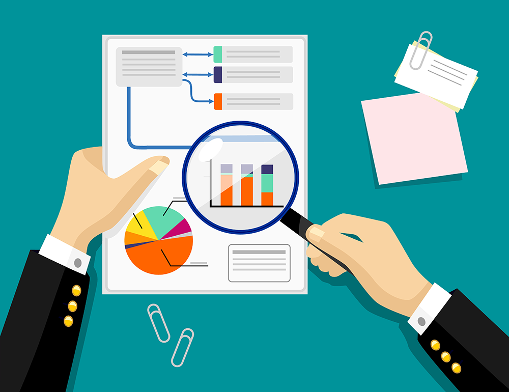

*Data Analysis leads to Information.*

- Data Analysis is set of tools and techniques.
- Discovering insightful, interesting, and novel patterns.
- Descriptive, understandable, and predictive models.
- Pattern mining, clustering, classification, and forecasting.

### Data Modeling

[figure not shown]

*Data Modeling - art and science of collecting and managing data.*

### Data Modeling

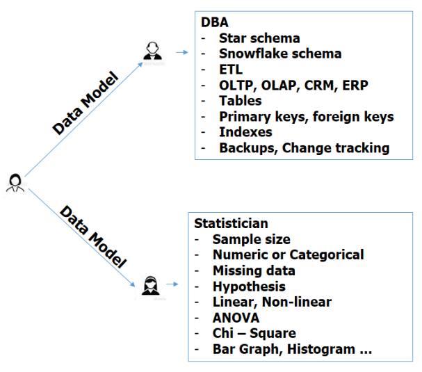

- Data Modeling starts with the collection of data.
- Represents how data should be structured and stored.
- Accurate use of data types numeric, categorical, dimensions.
- Naming convention and reserved words.
- Factors driving data primary keys, foreign keys, and constraints.

### Case - Study

Pew Research Center and Smithsonian magazine conducted a national survey *U.S. Views of Technology and the Future* which asked Americans about a wide range of potential scientific developments from near-term advances like robotics and bioengineering, to more “futuristic” possibilities like teleportation or space colonization. More information can be found at http://www.pewinternet.org/2014/04/17/us-views-of-technology-and-the-future/. PDF file *Feb_2014_Views_Future_Crosstab.pdf,* will be used to demonstrate relation between Data Analysis and Data Modeling.

### Report

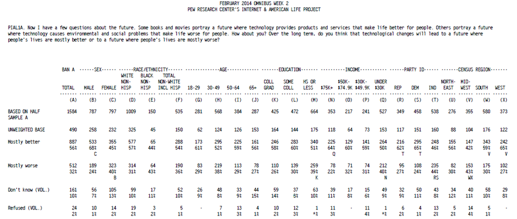

### Scope and Requirements

- This is crosstab report.
- Business Analyst needs partial data.
- Data needs to be stored in the RDBMS database.
- Showcase Star Schema and Snowflake Schema.

### Star Schema

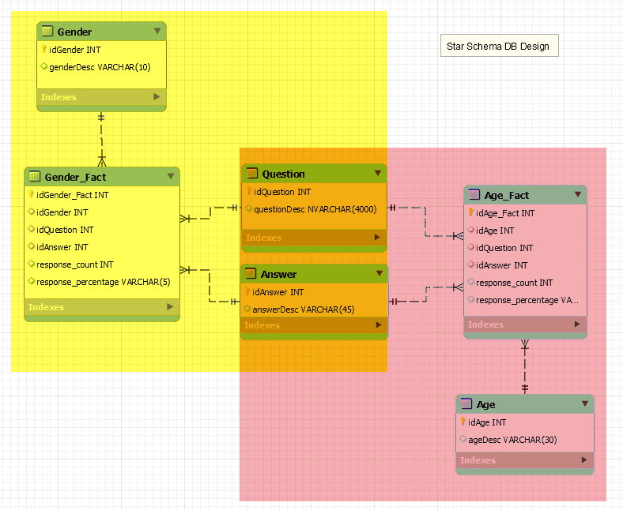

### Star Schema

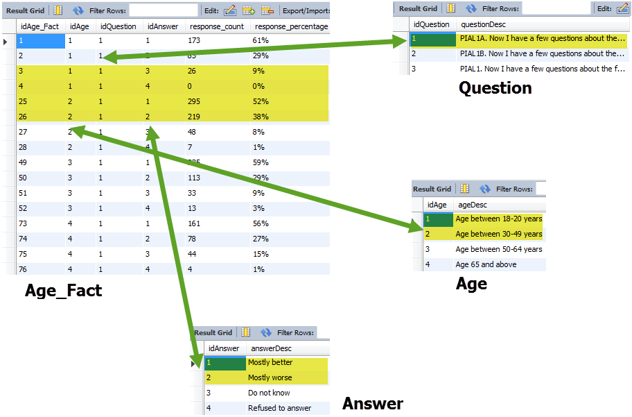

### Snowflake Schema

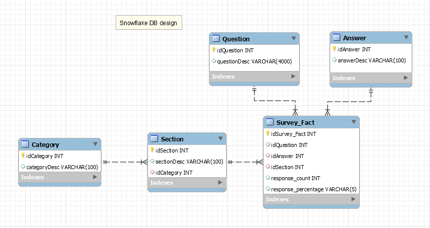

### Snowflake Schema Data

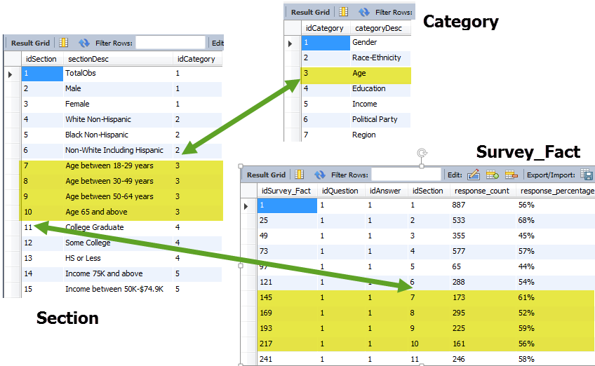

### Star Schema Vs. Snowflake Schema

Star

- Fact table uses more space.
- Queries are less complex.
- Suitable in data warehouses.

Snowflake Schema

- Fact table uses less space.
- Queries are more complex.
- Suitable for data marts.

### Star Schema - Storage

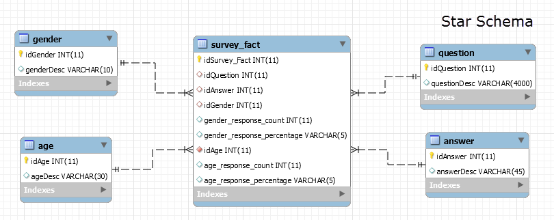

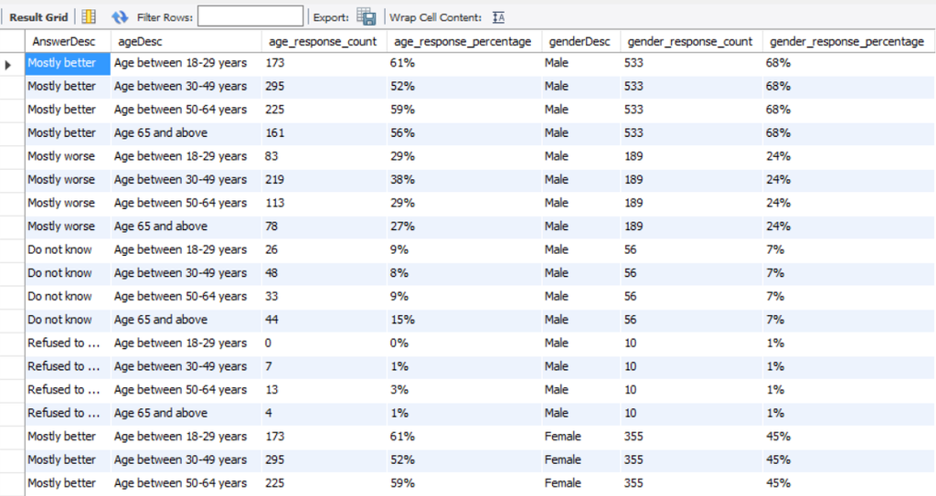

### Star Schema - Queries

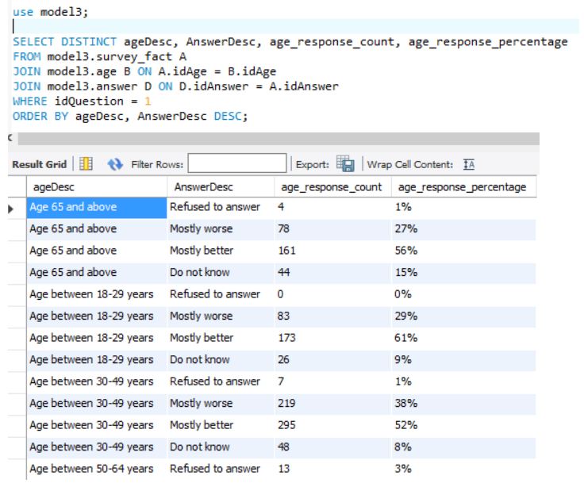

### Snowflake Schema - Queries

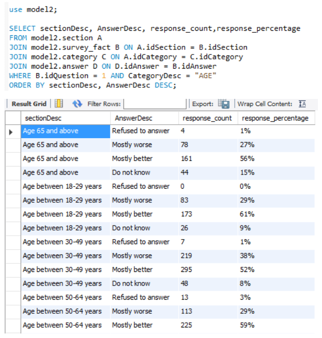